# Using oceandatr and minpatch to reduce fragmentation in a marine planning region (Seychelles)

# 1. Introduction

In many marine spatial planning problems, the goal is not only to meet representation targets at the lowest possible cost, but also to consider *how selected areas are arranged in space*. Highly fragmented marine protected areas can be difficult to manage and enforce. Small, isolated patches may not support viable populations or key ecological processes, and solutions that are scattered across space are often hard to explain to decision-makers and stakeholders.

Two R packages are particularly useful for addressing these challenges in a marine context.

- The `oceandatr` package provides a practical way to build realistic, analysis-ready marine planning datasets. It allows users to obtain marine planning boundaries such as exclusive economic zones or high-seas regions, generate planning-unit grids, and access global ocean datasets—including bathymetry, geomorphology, seamounts, and environmental conditions—that are aligned to those grids. Together, these capabilities make it much easier to assemble consistent inputs for marine spatial planning analyses.
- The `minpatch` package is a post-processing tool that modifies conservation planning solutions produced by `prioritizr` to reduce fragmentation. It enforces a user-defined minimum patch size by removing patches that are too small and adding new areas to maintain conservation targets. It then simplifies the solution by removing unnecessary planning units, while tracking how these changes affect patch structure and total cost.

In this vignette, we demonstrate the use of `oceandatr` and `minpatch` using a simple marine example from the Seychelles Exclusive Economic Zone. We first use `oceandatr` to construct a gridded planning problem with a small set of marine features and then solve a standard `prioritizr` minimum-set problem. We then apply `minpatch` to explore how different minimum patch sizes and boundary penalties influence fragmentation, and to assess whether `minpatch` behaves as expected in a realistic marine planning setting.

# 2. Study region and planning units with oceandatr

## 2.1 Load packages

```r
# if (!require(remotes)) install.packages("remotes")
# might need to increase timeout as it is a large package
# options(timeout = 9999)
# remotes::install_github("emlab-ucsb/oceandatr")
#install.packages("kableExtra")
library(oceandatr)
library(terra)
library(sf)
library(dplyr)
library(ggplot2)
library(patchwork)
library(prioritizr)
library(minpatch)
library(purrr)
library(tibble)
library(kableExtra)
set.seed(123)
# Note: oceandatr requires an up-to-date version of curl for data downloads
# install.packages("curl")
# packageVersion("curl")
```

## 2.2 Seychelles EEZ as the planning region

We start by using `get_boundary()` from `oceandatr` to obtain the Seychelles Exclusive Economic zone (EEZ). This defines our marine planning domain.

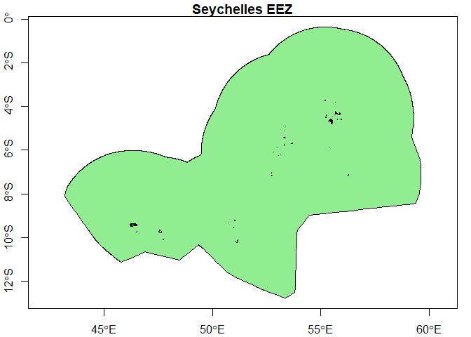

```r
Seychelles_eez <- get_boundary(name = "Seychelles")
# Note: needes to update the packageVersion of curl before this worked

# plot to check we have Seychelles' EEZ
plot(Seychelles_eez[1],
     col = "lightgreen",
     main = "Seychelles EEZ",
     axes = TRUE)
```

## 2.3 Choose an equal-area projection

We reproject the planning region into an equal-area projection to ensure that area- and distance-based calculations are meaningful.

```r
# use sf::st_bbox to get the bounding box coordinates (in lon/lat)
#sf::st_bbox(Seychelles_eez)

# use projectionwizard.org to choose an equal-area projection, then store as a PROJ string
# https://projectionwizard.org

projection_Seychelles <- "+proj=laea +lon_0=55 +lat_0=-4.5 +datum=WGS84 +units=m +no_defs"

# check CRS if needed
# sf::st_crs(projection_Seychelles)
```

## 2.4 Create a planning-unit grid

We now create a grid over the EEZ. To keep runtime moderate, we use a fairly coarse resolution. Our units will be in meters.

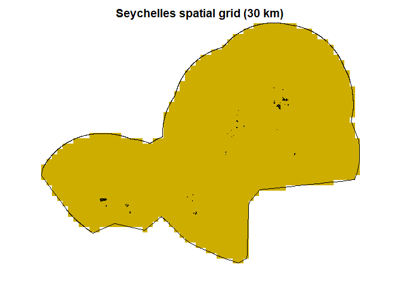

```r
# check which units to use
# sf::st_crs(projection_Seychelles,
#           parameters = TRUE)$units_gdal

# grid the planning area
Seychelles_grid <- get_grid(
  boundary   = Seychelles_eez,
  resolution = 30000, # 30,000 just to test the code but a finer resolution can be opted with a more powerful PC
  crs        = projection_Seychelles
)

# project the eez into same projection as grid for plotting
Seychelles_eez_proj <- Seychelles_eez %>%
  sf::st_transform(crs = projection_Seychelles) %>%
  sf::st_geometry()

# plot the grid
terra::plot(Seychelles_grid,
            col = "gold3",
            axes = FALSE,
            legend = FALSE,
            main = "Seychelles spatial grid (30 km)")
plot(Seychelles_eez_proj,
     add = TRUE,
     border = "black",
     lwd = 1)
```

Each *cell* of `Seychelles_grid` is a planning unit. To build a `prioritizr` problem later, it’s useful to have a vector version of the grid:

```r
# convert grid to sf polygons as minpatch only works with sf objects
Seychelles_pu <- Seychelles_grid %>%
terra::as.polygons(dissolve = FALSE) %>%
sf::st_as_sf()

# snap and validate geometry to avoid tiny gaps between cells [however, this does not work; we only snap the grid for counting the patches then]
# this helps ensure shared edges line up cleanly for patch adjacency
#if (!requireNamespace("lwgeom", quietly = TRUE)) install.packages("lwgeom")

#Seychelles_pu <- Seychelles_pu %>%
#  lwgeom::st_snap_to_grid(size = 1) %>%   # CRS units (metres)
#  sf::st_make_valid()

# assign planning unit ID and area (m²)
Seychelles_pu <- Seychelles_pu %>%
mutate(pu_id = row_number(),
       area_m2 = as.numeric(st_area(geometry)),
       cost   = area_m2 / 1e6        # convert meters2 to km2
)
# Note: our grid cells are 30km x 30 km, hence each cell is 900 square km

# check area in km² of each cell
Seychelles_pu$area_km2 <- as.numeric(st_area(Seychelles_pu)) / 1e6
summary(Seychelles_pu$area_km2)
```

```
#>    Min. 1st Qu.  Median    Mean 3rd Qu.    Max.
#>   900.2   900.2   900.2   900.2   900.2   900.2
```

```r
# check approx side length in km (sqrt(area)) of each cell
Seychelles_pu$side_km <- sqrt(Seychelles_pu$area_km2)
summary(Seychelles_pu$side_km)
```

```
#>    Min. 1st Qu.  Median    Mean 3rd Qu.    Max.
#>      30      30      30      30      30      30
```

**Notes:**

- *Raise an issue* in MinPatch repository to snap and validate geometry so that patches are counted correctly (using Rook’s method)
- *Submit a pull request* related to how it counts the patches (recount the patches in the table);
- Snapping the grid before the start of the prioritisation is problematic because it results into a patchy baseline solution. Thus, we just snap the grid for counting then.

# 3. Building marine features with oceandatr

To keep the example focused, we will use a small set of features obtained using `oceandatr`:

- bathymetric depth zones
- geomorphology - seafloor features (banks, ridges, etc.)
- knolls
- seamounts
- coral habitat
- environmental zones - clusters of environmental conditions

## 3.1 Bathymetry, geomorphology, and knolls

We could retrieve raw bathymetry, but for minpatch tests we mainly need *binary features* that create patch structure. Using `oceandatr`, we retrieve bathymetric depth zones, seafloor geomorphology classes, and knolls, all of which are already gridded to `Seychelles_grid`.

#### Bathymetry

We start with bathymetry. Rather than using raw depth values, we classify bathymetry into discrete depth zones (*e.g.*, epipelagic, mesopelagic, bathypelagic, and abyssopelagic).

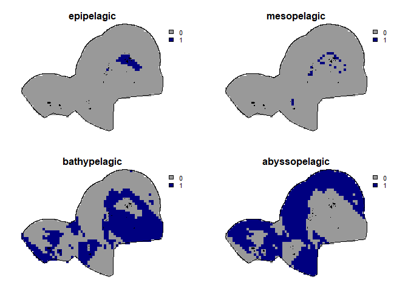

```r
# get bathymetry with classifications into different depth zones
depth_zones <- get_bathymetry(spatial_grid = Seychelles_grid,
                             classify_bathymetry = TRUE)
# this may take seconds to minutes, depending on grid size

# plot
terra::plot(depth_zones,
            col = c("grey60", "navyblue"),
            axes = FALSE, fun =
              function(){terra::lines(terra::vect(Seychelles_eez_proj))})
```

```r
# value of 1 indicates that depth zone is present
```

#### Geomorphology

Next, we include seafloor geomorphology. These layers represent distinct physical features of the seabed (e.g. banks and ridges).

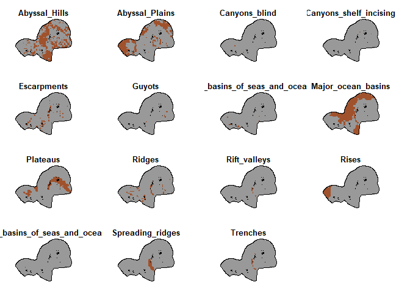

```r
geomorphology <- get_geomorphology(spatial_grid =
                                     Seychelles_grid) %>%
  remove_empty_layers() # can remove any empty layers so we don't have so many layers to plot

# brown colour indicates that geomorphological feature is present
terra::plot(geomorphology,
            col = data.frame(c(0,1),
                             c("grey60", "sienna")),
            axes = FALSE,
            legend = FALSE,
            fun = function(){terra::lines(terra::vect(Seychelles_eez_proj))})
```

#### Knolls

Knolls are small, isolated topographic features that often form compact patches.

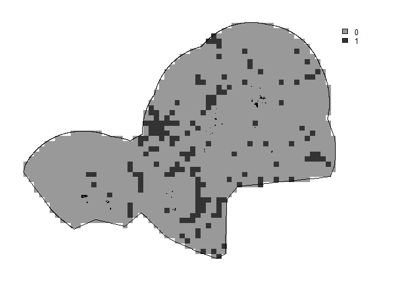

```r
knolls <- get_knolls(spatial_grid = Seychelles_grid)

#value of 1 indicates that knolls are present
terra::plot(knolls,
            col = c("grey60", "grey20"),
            axes = FALSE)
plot(Seychelles_eez_proj, add=TRUE)
```

## 3.2 Seamounts and coral habitat

#### Seamounts

Seamounts are typically important biodiversity features. We buffer seamount peaks by 30 km so patches are not too tiny at our grid resolution.

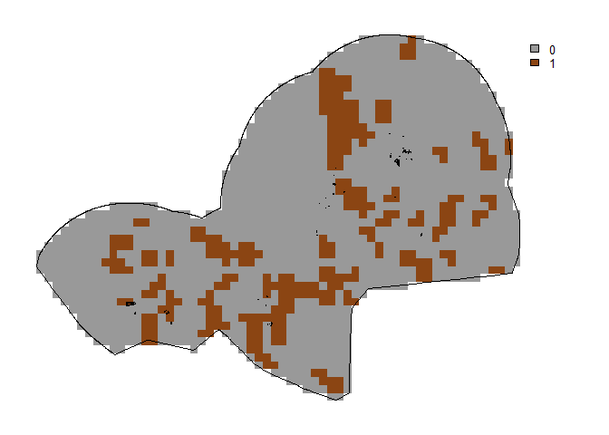

```r
# spatial grid units are meters, so set buffer to 30000 m = 30 km
seamounts <- get_seamounts(spatial_grid = Seychelles_grid,
                           buffer       = 30000  # 30 km
                           )

# value of 1 indicates that seamount is present
terra::plot(seamounts,
            col = c( "grey60", "saddlebrown"),
          #  main = "Seamount areas (buffered)",
            axes = FALSE)
plot(Seychelles_eez_proj,
     add = TRUE,
     border = "black")
```

#### Coral habitat

Coral habitat here refers to deep-sea coral assemblages, such as antipatharians, cold-water corals, and octocorals, that form structurally complex habitats on hard substrates in deeper waters.

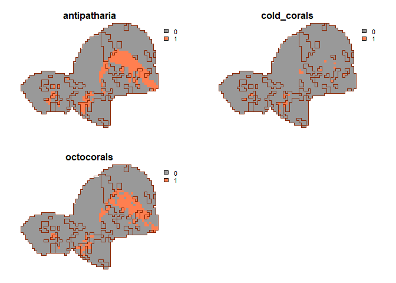

```r
coral_habitat <- get_coral_habitat(spatial_grid = Seychelles_grid)

#show the seamounts areas on the plot: coral habitat is often on seamounts which are shallower than surrounding ocean floor

#value of 1 indicates that coral is present
terra::plot(coral_habitat,
            col = c("grey60", "coral"),
            axes = FALSE,
            fun = function()terra::lines(terra::as.polygons(seamounts, dissolve = TRUE), col = "orangered4"))
```

## 3.3 Environmental zones

We also create environmental zones derived from Bio-ORACLE variables. To keep vignette fast, we use only 3 clusters.

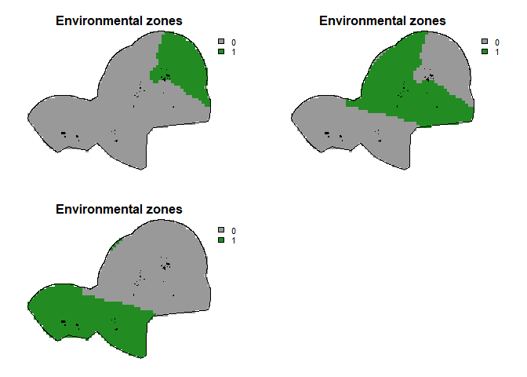

```r
#set number of clusters to 3 to reduce runtime and memory usage
enviro_zones <- get_enviro_zones(spatial_grid = Seychelles_grid,
                                 show_plots   = FALSE,
                                 num_clusters = 3)

#value of 1 indicates that environmental zone is present
terra::plot(enviro_zones,
            col = c("grey60", "forestgreen"),
            main = "Environmental zones",
            axes = FALSE,
            fun = function(){terra::lines(terra::vect(Seychelles_eez_proj))})
```

## 3.4 Build a feature stack

We now combine all feature layers into a single `SpatRaster` object. This stack serves as the set of conservation features that will later be linked to each planning unit.

```r
# subset geomorphology to a few representative layers
geomorph_subset <- geomorphology[[1:min(3, nlyr(geomorphology))]]

# give each layer a clear and unique name
names(depth_zones)      <- paste0("depth_zone_",  seq_len(nlyr(depth_zones)))      # 4 layers
names(geomorph_subset)  <- paste0("geomorph_",    seq_len(nlyr(geomorph_subset)))  # up to 3
names(knolls)           <- "knolls"                                                 # 1 layer
names(seamounts)        <- "seamounts"                                              # 1 layer
names(coral_habitat)    <- paste0("coral_",       seq_len(nlyr(coral_habitat)))    # 3 layers
names(enviro_zones)     <- paste0("env_zone_",    seq_len(nlyr(enviro_zones)))     # n clusters

# stack everything into a single SpatRaster
Seychelles_features <- c(
  depth_zones,
  geomorph_subset,
  knolls,
  seamounts,
  coral_habitat,
  enviro_zones
)
```

Before using the feature stack, we restrict it to the planning region so that only cells inside the Seychelles EEZ are retained.

```r
# convert EEZ geometry to a terra vector for masking
eez_vect <- terra::vect(Seychelles_eez_proj)

# Only keep raster cells found within the EEZ
Seychelles_features <- terra::mask(Seychelles_features, eez_vect)

# check the number of cells that have the feature present in each layer
feature_counts <- terra::global(Seychelles_features, "sum", na.rm = TRUE)
names(feature_counts) <- "n_cells_present"
feature_counts
```

```
#>              n_cells_present
#> depth_zone_1              36
#> depth_zone_2              24
#> depth_zone_3             601
#> depth_zone_4             839
#> geomorph_1               544
#> geomorph_2               387
#> geomorph_3                 2
#> knolls                   153
#> seamounts                287
#> coral_1                  213
#> coral_2                   21
#> coral_3                  171
#> env_zone_1               278
#> env_zone_2               636
#> env_zone_3               586
```

# 4. Attach feature values to planning units

To use these features in a `prioritizr` problem, we need feature values summarised at the planning-unit level rather than at the raster-cell level.

## 4.1 Extract raster features to planning units

Here, we overlay the planning-unit polygons on the raster feature stack and extract feature values for each planning unit, as minpatch only works with sf objects.

```r
# convert planning units (sf) to terra vector
pu_vect <- terra::vect(Seychelles_pu)

# extract feature values for each planning unit polygon
# for each planning unit polygon, we look at all raster cells inside it and return the values of each feature layer
feature_df <- terra::extract(Seychelles_features,
                             pu_vect,
                             ID = FALSE)
# the result will be one row per polygon, with one column per raster layer

# to check whether the rows in extracted feature data is equal to number of planning units (to see if overlay worked, they must match)
nrow(feature_df)
```

```
#> [1] 1500
```

```r
nrow(Seychelles_pu)
```

```
#> [1] 1500
```

```r
# bind extracted feature values to planning-unit attributes
Seychelles_sf <- dplyr::bind_cols(
  Seychelles_pu,
  as.data.frame(feature_df)
)

# store feature column names
feature_cols <- names(Seychelles_features)
```

## 4.2 Convert features to binary presence–absence

For this example, we treat all features as binary, indicating whether a feature is present or absent in each planning unit.

```r
# convert to binary (similar to Tas example)
Seychelles_sf <- Seychelles_sf  %>%
  mutate(across(all_of(feature_cols), ~ if_else(.x > 0, 1, 0)))

# quick check: how many PUs have values in each feature)
Seychelles_sf %>%
  sf::st_drop_geometry() %>%
  dplyr::summarise(dplyr::across(dplyr::all_of(feature_cols), sum)) %>%
  tidyr::pivot_longer(
    cols = everything(),
    names_to = "feature",
    values_to = "n_pu_present"
  )
```

```
#> # A tibble: 15 × 2
#>    feature      n_pu_present
#>    <chr>               <dbl>
#>  1 depth_zone_1           36
#>  2 depth_zone_2           24
#>  3 depth_zone_3          601
#>  4 depth_zone_4          839
#>  5 geomorph_1            544
#>  6 geomorph_2            387
#>  7 geomorph_3              2
#>  8 knolls                153
#>  9 seamounts             287
#> 10 coral_1               213
#> 11 coral_2                21
#> 12 coral_3               171
#> 13 env_zone_1            278
#> 14 env_zone_2            636
#> 15 env_zone_3            586
```

```r
# this should match the raster feature stack earlier
```

# 5. Build and solve a `prioritizr` problem

We now build a simple minimum-set problem using `prioritizr`, with equal-weight features and a uniform target of 30% for each feature.

```r
# build the problem using sf planning units + feature columns

p_base <-
  prioritizr::problem(
    x              = Seychelles_sf,
    features       = feature_cols,
    cost_column    = "cost"
  ) %>%
  add_min_set_objective() %>%
  add_relative_targets(0.30) %>% # 30% of each feature
  add_binary_decisions() %>%
  add_rsymphony_solver(verbose = FALSE) # change this to cbc later

p_base
```

```
#> A conservation problem (<ConservationProblem>)
#> ├•data
#> │├•features:    "depth_zone_1", "depth_zone_2", "depth_zone_3", … (15 total)
#> │└•planning units:
#> │ ├•data:       <sf> (1500 total)
#> │ ├•costs:      continuous values (between 900.2126 and 900.2126)
#> │ ├•extent:     -1301436, -912664.9, 511794.5, 457589 (xmin, ymin, xmax, ymax)
#> │ └•CRS:        +proj=laea +lat_0=-4.5 +lon_0=55 +x_0=0 +y_0=0 +datum=WGS84 +units=m +no_defs (projected)
#> ├•formulation
#> │├•objective:   minimum set objective
#> │├•penalties:   none specified
#> │├•features:
#> ││├•targets:    relative targets (all equal to 0.3)
#> ││└•weights:    none specified
#> │├•constraints: none specified
#> │└•decisions:   binary decision
#> └•optimization
#>  ├•portfolio:   default portfolio
#>  └•solver:      rsymphony solver (`gap` = 0.1, `time_limit` = 2147483647, `first_feasible` = FALSE, …)
#> # ℹ Use `summary(...)` to see complete formulation.
```

We then solve this baseline problem without any fragmentation controls and use it as a reference for the MinPatch experiments.

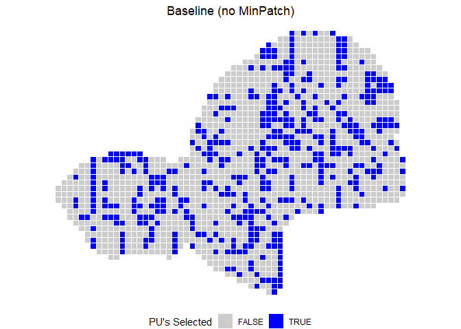

```r
# solve the baseline problem
t_base <- system.time({
  s_base <- solve(p_base)
})

# Plot the baseline solution
p_base_plot <- plot_prioritizr(s_base) +
  ggtitle("Baseline (no MinPatch)")

p_base_plot
```

In this baseline solution, we see that the selected planning units are fragmented and scattered across the planning region. There is no apparent compact areas, which are theoretically better when it comes to managing protected areas.

# 6. Set up MinPatch parameters

We define minimum patch sizes relative to the planning units by scaling the **median PU area** by `multipliers` (5×, 10×, 20×). This makes the thresholds easy to interpret as “roughly how many planning units per patch”. We also set a single **`patch_radius`** for all runs, chosen to represent a neighbourhood of about 10 planning units. This radius defines the spatial search distance used by MinPatch to identify neighbouring planning units when forming, expanding, or merging patches.

```r
# median planning-unit area (m² and km²)
median_pu_area_m2 <- median(Seychelles_sf$area_m2)
median_pu_area_km2 <- median_pu_area_m2 / 1e6

# multipliers relative to the median PU area
multipliers <- c(5, 10, 20)

# minimum patch sizes in m² and km²
patch_sizes_m2  <- multipliers * median_pu_area_m2
patch_sizes_km2 <- patch_sizes_m2 / 1e6

# patch radius: roughly a circle that covers ~10 PUs (in meters)
patch_radius <- sqrt(median_pu_area_m2 * 10 / pi)

# summary table
minpatch_param_summary <- tibble::tibble(
  multiplier       = multipliers,
  min_patch_m2     = patch_sizes_m2,
  min_patch_km2    = patch_sizes_km2,
  median_pu_m2     = median_pu_area_m2,
  median_pu_area_km2 = median_pu_area_km2)

# summaries of the different values
cat("\nMinPatch parameters (relative to planning units):\n")
```

```
#>
#> MinPatch parameters (relative to planning units):
```

```r
cat("- Median planning unit area:",
    round(median_pu_area_km2, 3), "km^2\n\n")
```

```
#> - Median planning unit area: 900.213 km^2
```

```r
for (i in seq_along(multipliers)) {
  cat("Multiplier:", multipliers[i], "x median PU area\n")
  cat("  - Minimum patch size:",
      round(patch_sizes_km2[i], 2), "km^2\n")
  cat("  - Corresponds to ≈",
      round(patch_sizes_km2[i] / median_pu_area_km2, 2),
      "planning units\n\n")
}
```

```
#> Multiplier: 5 x median PU area
#>   - Minimum patch size: 4501.06 km^2
#>   - Corresponds to ≈ 5 planning units
#>
#> Multiplier: 10 x median PU area
#>   - Minimum patch size: 9002.13 km^2
#>   - Corresponds to ≈ 10 planning units
#>
#> Multiplier: 20 x median PU area
#>   - Minimum patch size: 18004.25 km^2
#>   - Corresponds to ≈ 20 planning units
```

```r
median_pu_length <- sqrt(median_pu_area_m2)
patch_radius_cells <- patch_radius / median_pu_length

cat("Patch radius used for all runs:\n")
```

```
#> Patch radius used for all runs:
```

```r
cat("  -", round(patch_radius, 1), "m (≈",
    round(patch_radius / 1000, 2), "km)\n")
```

```
#>   - 53530 m (≈ 53.53 km)
```

```r
cat("  - Corresponds to ≈",
    round(patch_radius_cells, 2),
    "median planning-unit lengths\n")
```

```
#>   - Corresponds to ≈ 1.78 median planning-unit lengths
```

**Notes:**

- When calculating patch radius, it should be divided by pi. This is because we are getting the radius of the circle from the centroid of the starting patch when trying to expand patches.
- Moreover, it would be better for the user to have the option to set the actual size of their patch rather than inputting a multiplier. This would be useful for the app.

# 7. Run MinPatch for different minimum patch sizes

We now run MinPatch once for each minimum patch factor using the different multipliers. Each run starts from the same `prioritizr` solution but applies different constraints on minimum patch size.

```r
minpatch_results <- vector("list", length(patch_sizes_m2))
minpatch_times <- numeric(length(patch_sizes_m2))

for (i in seq_along(patch_sizes_m2)) {

cat("\n============================================\n")
cat("Running MinPatch with min patch area ~",
    round(patch_sizes_km2[i], 2), "km^2 (",
    multipliers[i], "x median PU)\n")
cat("============================================\n")

  # time the MinPatch run
  t_mp <- system.time({
     minpatch_results[[i]] <- run_minpatch(
    prioritizr_problem   = p_base,
    prioritizr_solution  = s_base,
    min_patch_size       = patch_sizes_m2[i],
    patch_radius         = patch_radius,
    boundary_penalty     = 0,
    remove_small_patches = TRUE,
    add_patches          = TRUE,
    whittle_patches      = TRUE,
    verbose              = TRUE
  )

  })

  # store elapsed time (seconds)
  minpatch_times[i] <- t_mp[["elapsed"]]
}
```

[output not shown]

[output cut: 264 more lines]

```
#>     New keystone units: 0
#>     Scoreable units: 461
#>     Unit 202 cannot be removed - adding to keystone set
#>     Unit 203 cannot be removed - adding to keystone set
#>     Unit 231 cannot be removed - adding to keystone set
#>     Unit 232 cannot be removed - adding to keystone set
#>     Unit 233 cannot be removed - adding to keystone set
#>     Unit 234 cannot be removed - adding to keystone set
#>   Whittling iteration 100
#>   Whittling iteration 200
#>   Whittling iteration 300
#>   Whittling iteration 400
#>   No more edge units to consider - terminating
#> Calculating final statistics...
#> MinPatch processing complete!
```

```r
# name the outputs
names(minpatch_results) <- paste0("minpatch_", multipliers, "x")
names(minpatch_times)   <- paste0("minpatch_", multipliers, "x")
```

# 8. Interpreting MinPatch outcomes

In this section, we interpret how MinPatch modifies the baseline solution. We compare resulting spatial patterns, patch structure, and trade-offs between fragmentation and cost.

### 8.1 Selected planning units (baseline vs MinPatch runs)

We start by showing only the selected planning units for the baseline and each MinPatch run.

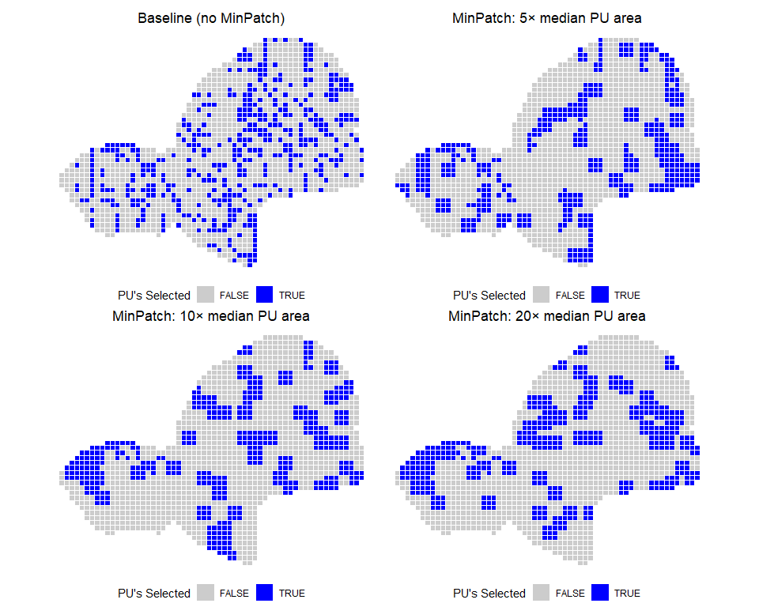

```r
# Helper to extract the solution and ensure a `solution_1` column
get_solution_with_solution1 <- function(x) {
  sol <- x$solution
  extra_cols <- setdiff(names(sol), names(x$planning_units))
  if (!"solution_1" %in% names(sol) && length(extra_cols) >= 1) {
    sol$solution_1 <- sol[[extra_cols[1]]]
  }
  sol
}

# Baseline solution
p_base_plot2 <- plot_prioritizr(s_base) +
  ggtitle("Baseline (no MinPatch)")

library(patchwork)

# MinPatch solution plots
sol_list <- purrr::map(minpatch_results, get_solution_with_solution1)

p_list <- purrr::map2(
  sol_list,
  multipliers,
  ~ plot_prioritizr(.x) +
    ggtitle(paste0("MinPatch: ", .y, "× median PU area"))
)

p_1 <- p_list[[1]]
p_2 <- p_list[[2]]
p_3 <- p_list[[3]]

# baseline plot (rename!)
p_base_plot <- plot_prioritizr(s_base) +
  ggtitle("Baseline (no MinPatch)")

# 2×2 layout:
(p_base_plot | p_1) /
(p_2        | p_3)
```

The baseline solution is highly fragmented, with many small and isolated selected planning units. As the minimum patch size increases, these small patches are removed or merged, leading to fewer, larger, and more spatially coherent patches. Overall, higher MinPatch thresholds produce a clearer and less fragmented spatial pattern of selected areas.

### 8.2 Group summary table (all runs)

Having examined the spatial solutions, we summarise all runs in a single table to compare outcomes across different metrics.

```r
library(dplyr)
library(tibble)
library(purrr)
library(kableExtra)

# helper to extract metrics from compare_solutions() output
get_metric <- function(overall, column, metric) {
  out <- overall[[column]][overall$Metric == metric]
  if (length(out) == 0) NA_real_ else out
}

# ---- MinPatch parameter info ----
median_pu_area_m2  <- median(Seychelles_sf$area_m2)

patch_sizes_m2  <- multipliers * median_pu_area_m2
patch_sizes_km2 <- patch_sizes_m2 / 1e6

min_patch_lookup <- tibble::tibble(
  multiplier    = multipliers,
  min_patch_km2 = patch_sizes_km2
)

# ---- Runtime lookup (seconds) ----
# baseline runtime left as NA (add t_base[["elapsed"]] if you want it)
runtime_lookup <- tibble::tibble(
  scenario    = c("Baseline", paste0("MinPatch ×", multipliers)),
  runtime_sec = c(NA_real_, as.numeric(minpatch_times))
)

# ---- Baseline metrics (same "Original" across runs) ----
overall0 <- compare_solutions(minpatch_results[[1]])$overall

baseline_row <- tibble::tibble(
  scenario                 = "Baseline",
  multiplier               = NA_real_,
  min_patch_size_km2       = NA_real_,
  selected_pu              = get_metric(overall0, "Original", "Selected Planning Units"),
  total_area_km2           = get_metric(overall0, "Original", "Total Area") / 1e6,
  n_patches                = get_metric(overall0, "Original", "Number of Patches"),
  valid_patches_ge_min     = get_metric(overall0, "Original", "Valid Patches (>= min size)"),
  median_patch_km2         = get_metric(overall0, "Original", "Median Patch Size") / 1e6,
  total_pu_cost            = get_metric(overall0, "Original", "Planning Unit Cost"),
  boundary_cost            = get_metric(overall0, "Original", "Boundary Cost"),
  overall_cost             = get_metric(overall0, "Original", "Total Cost")
)

# ---- MinPatch metrics ----
minpatch_rows <- purrr::map2_dfr(minpatch_results, multipliers, ~{
  overall <- compare_solutions(.x)$overall

  tibble::tibble(
    scenario                 = paste0("MinPatch ×", .y),
    multiplier               = .y,
    min_patch_size_km2       = min_patch_lookup$min_patch_km2[min_patch_lookup$multiplier == .y],
    selected_pu              = get_metric(overall, "MinPatch", "Selected Planning Units"),
    total_area_km2           = get_metric(overall, "MinPatch", "Total Area") / 1e6,
    n_patches                = get_metric(overall, "MinPatch", "Number of Patches"),
    valid_patches_ge_min     = get_metric(overall, "MinPatch", "Valid Patches (>= min size)"),
    median_patch_km2         = get_metric(overall, "MinPatch", "Median Patch Size") / 1e6,
    total_pu_cost            = get_metric(overall, "MinPatch", "Planning Unit Cost"),
    boundary_cost            = get_metric(overall, "MinPatch", "Boundary Cost"),
    overall_cost             = get_metric(overall, "MinPatch", "Total Cost")
  )
})

# ---- Combine and format table ----
solution_summary <- bind_rows(baseline_row, minpatch_rows) %>%
  left_join(runtime_lookup, by = "scenario") %>%
  mutate(
    multiplier = if_else(is.na(multiplier), "-", as.character(multiplier)),
    across(c(selected_pu, n_patches, valid_patches_ge_min), ~ as.integer(round(.x))),
    across(c(min_patch_size_km2, total_area_km2, median_patch_km2), ~ round(.x, 2)),
    across(c(total_pu_cost, boundary_cost, overall_cost), ~ round(.x, 2)),
    runtime_sec = round(runtime_sec, 1)
  ) %>%
  select(
    scenario,
    `Multiplier`                  = multiplier,
    `Minimum patch size (km²)`    = min_patch_size_km2,
    `Selected PUs`                = selected_pu,
    `Total area (km²)`            = total_area_km2,
    `# patches`                   = n_patches,
    `Valid patches (>= min size)` = valid_patches_ge_min,
    `Median patch size (km²)`     = median_patch_km2,
    `Total PU cost`               = total_pu_cost,
    `Boundary cost`               = boundary_cost,
    `Overall cost`                = overall_cost,
    `Runtime (s)`                 = runtime_sec
  )

knitr::kable(solution_summary, format = "html", align = "l") |>
  kableExtra::kable_styling(
    bootstrap_options = c("striped", "hover", "condensed", "responsive"),
    full_width = FALSE,
    position = "left"
  ) |>
  kableExtra::row_spec(0, bold = TRUE)
```

scenario

Multiplier

Minimum patch size (km²)

Selected PUs

Total area (km²)

# patches

Valid patches (>= min size)

Median patch size (km²)

Total PU cost

Boundary cost

Overall cost

Runtime (s)

Baseline

NA

452

406896.1

176

18

1800.43

414097.8

0

414097.8

NA

MinPatch ×5

5

4501.06

460

414097.8

72

35

4501.06

414097.8

0

414097.8

723.2

MinPatch ×10

10

9002.13

458

412297.4

81

12

2700.64

412297.4

0

412297.4

856.8

MinPatch ×20

20

18004.25

466

419499.1

81

1

3600.85

419499.1

0

419499.1

758.8

We also see that only the 5× run has a median patch size equal to the minimum patch size. In contrast, for the 10× and 20× runs, the median patch size falls well below the threshold. This suggests that, at higher multipliers, MinPatch attempts to enforce the minimum patch-size rule while still achieving conservation targets, but is unable to do so consistently across all patches.

### 8.3 Change maps (Added / Removed / Retained / No change)

After comparing the different runs, we now examine how planning units were added, removed, or retained relative to the baseline solution using `plot_minpatch`. Using this functionm, we create maps that provide a visual explanation of how MinPatch modifies the solution to enforce minimum patch sizes and reduce fragmentation.

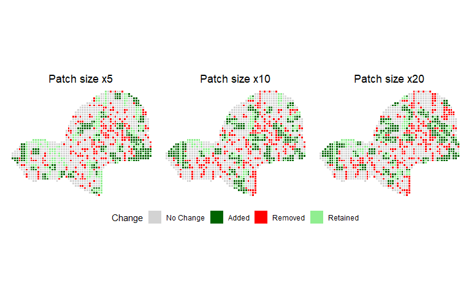

```r
# Create plots for each minpatch run and arrange them with patchwork
plot_list <- purrr::map2(
  minpatch_results,
  multipliers,
  ~ plot_minpatch(
      .x,
      title = paste0("Patch size x", .y)
    )
)
patchwork::wrap_plots(
  plotlist = plot_list,
  guides   = "collect",
  ncol     = 3
) &
  theme(legend.position = "bottom")
```

Across the three runs, increasing the multiplier leads to a clearer separation between core planning units that are retained and more peripheral units that are added or removed. As the minimum patch size increases, a larger share of the retained planning units corresponds to core areas that persist across runs, while changes are increasingly concentrated in the surrounding areas. At higher multipliers, we observe more turnover, with more planning units being added and removed as MinPatch restructures the solution to meet the patch-size constraint. This suggests that higher multipliers enforce stronger spatial consolidation by stabilising core areas while allowing greater reconfiguration at the edges.

**Notes:**

- The plot colors are not that colour-blind friendly.

### 8.4 Patch-labelled maps

Since Section 8.3 shows *where* MinPatch added and removed planning units, we now zoom in on *how selected planning units cluster into patches*. In particular, we label each patch and classify it as **valid** (meets the minimum patch-size rule) or **invalid** (falls below the threshold). This view makes the spatial definition of a “patch” explicit and helps interpret the patch statistics in the summary table (Section 8.2), especially the reported number of patches and the number of valid patches.

A key point is that patch counts depend on how we define “connected”. Two common neighbourhood rules are the **rook** and **queen** methods. Under **rook adjacency**, two planning units are considered connected only if they share an *edge* (north, south, east, or west). Under **queen adjacency**, planning units are considered connected if they share an edge *or a corner* (diagonal contact also counts). In gridded planning problems, the queen method usually produces *fewer* patches because diagonal contacts can link otherwise separate clusters.

In this vignette, we use **rook adjacency** to delineate patches. For management and ecological interpretation, rook-connected patches are often more defensible because they reflect *contiguous area* (shared boundary length) rather than corner-touching units that may be connected only at a single point. This makes the resulting patches more compact and easier to interpret as coherent areas, especially in a square-grid setting. We therefore treat rook adjacency as the primary patch definition for assessing whether patches meet the minimum size requirement.

```
#> MinPatch 5x: 29 patches | 23 valid | 6 invalid (threshold = 4501.06 km²)
```

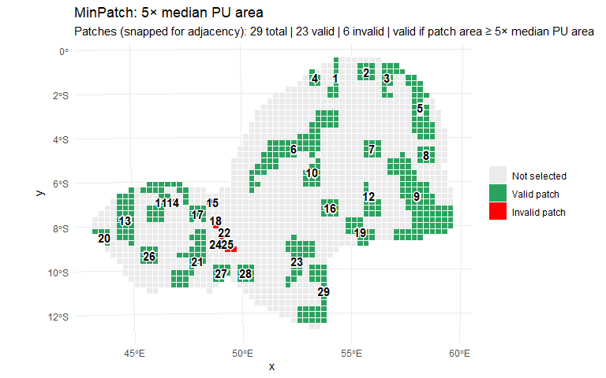

```
#> MinPatch 10x: 22 patches | 13 valid | 9 invalid (threshold = 9002.13 km²)
```

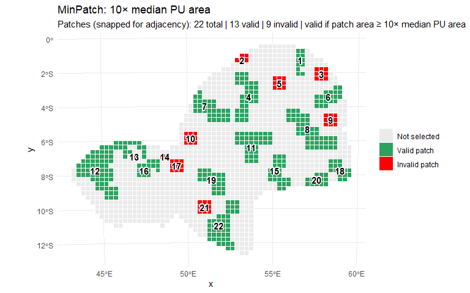

```
#> MinPatch 20x: 22 patches | 6 valid | 16 invalid (threshold = 18004.25 km²)
```

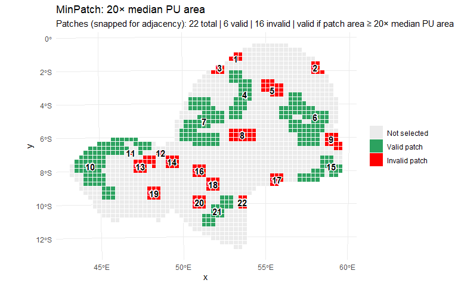

```r
library(igraph)
library(shadowtext)

if (!requireNamespace("lwgeom", quietly = TRUE)) {
  install.packages("lwgeom")
}

# Helper: compute rook-adjacency patches + classify valid/invalid by area threshold
# return = "plot"   -> returns ggplot object (default)
# return = "counts" -> returns a tibble with rook-based patch counts
plot_patch_validity <- function(multiplier, return = c("plot", "counts")) {

  return <- match.arg(return)

  # locate run
  i_run <- which(multipliers == multiplier)
  stopifnot(length(i_run) == 1)

  sol <- minpatch_results[[i_run]]$solution
  stopifnot("minpatch" %in% names(sol))

  # ensure consistent PU id for joins/labels
  sol <- sol %>%
    mutate(
      pu_id    = row_number(),
      selected = (minpatch == 1)
    )

  # threshold area (m²): multiplier × median PU area
  if (!exists("median_pu_area_m2")) {
    median_pu_area_m2 <- median(Seychelles_sf$area_m2)
  }
  min_patch_area_m2 <- multiplier * median_pu_area_m2

  # selected units only (for patch detection)
  sel <- sol %>% filter(selected)
  stopifnot(nrow(sel) > 0)

  # snap & validate for adjacency reliability (only for patch counting/unioning)
  sel2 <- sel %>%
    lwgeom::st_snap_to_grid(size = 1) %>%   # CRS units (metres)
    sf::st_make_valid()

  # rook adjacency = edge sharing only (works reliably for snapped grids)
  nb_list <- sf::st_relate(sel2, sel2, pattern = "F***1****")

  edges <- do.call(
    rbind,
    lapply(seq_along(nb_list), function(i) {
      if (length(nb_list[[i]]) == 0) return(NULL)
      cbind(from = i, to = nb_list[[i]])
    })
  )

  g <- igraph::make_empty_graph(n = nrow(sel2), directed = FALSE)
  if (!is.null(edges) && nrow(edges) > 0) {
    g <- igraph::add_edges(g, as.vector(t(edges)))
  }

  comp <- igraph::components(g)
  sel2$patch_id <- comp$membership

  # patch polygons + patch size (area) + validity
  patch_info <- sel2 %>%
    group_by(patch_id) %>%
    summarise(
      n_pu       = dplyr::n(),
      patch_area = sum(as.numeric(st_area(geometry)), na.rm = TRUE),
      geometry   = st_union(geometry),
      .groups    = "drop"
    ) %>%
    st_as_sf() %>%
    mutate(
      is_valid = patch_area >= min_patch_area_m2,
      label_pt = st_point_on_surface(geometry)
    )

  # label coords
  xy <- st_coordinates(patch_info$label_pt)
  patch_info$x <- xy[, 1]
  patch_info$y <- xy[, 2]

  # counts
  n_patches         <- nrow(patch_info)
  n_valid_patches   <- sum(patch_info$is_valid)
  n_invalid_patches <- n_patches - n_valid_patches

  if (return == "counts") {
    return(tibble::tibble(
      scenario          = paste0("MinPatch ×", multiplier),
      new_n_patches     = as.integer(n_patches),
      new_valid_patches = as.integer(n_valid_patches)
    ))
  }

  # join validity back to PUs
  sel_class <- sel2 %>%
    st_drop_geometry() %>%
    select(pu_id, patch_id) %>%
    left_join(
      patch_info %>% st_drop_geometry() %>% select(patch_id, is_valid),
      by = "patch_id"
    ) %>%
    mutate(status = ifelse(is_valid, "Valid patch", "Invalid patch"))

  sol_plot <- sol %>%
    left_join(sel_class %>% select(pu_id, status), by = "pu_id") %>%
    mutate(
      status = ifelse(is.na(status), "Not selected", status),
      status = factor(status, levels = c("Not selected", "Valid patch", "Invalid patch"))
    )

  # console message
  cat(
    "MinPatch ", multiplier, "x: ",
    n_patches, " patches | ",
    n_valid_patches, " valid | ",
    n_invalid_patches, " invalid",
    " (threshold = ", round(min_patch_area_m2 / 1e6, 2), " km²)\n",
    sep = ""
  )

  # plot
  ggplot() +
    geom_sf(
      data = sol_plot,
      aes(fill = status),
      colour = "white",
      linewidth = 0.15
    ) +
    shadowtext::geom_shadowtext(
      data = patch_info,
      aes(x = x, y = y, label = patch_id),
      size = 4,
      fontface = "bold",
      colour = "black",
      bg.colour = "white",
      bg.r = 0.12
    ) +
    scale_fill_manual(
      values = c(
        "Not selected"  = "grey92",
        "Valid patch"   = "#2ca25f",
        "Invalid patch" = "red"
      )
    ) +
    labs(
      title = paste0("MinPatch: ", multiplier, "× median PU area"),
      subtitle = paste0(
        "Patches (snapped for adjacency): ",
        n_patches, " total | ",
        n_valid_patches, " valid | ",
        n_invalid_patches, " invalid",
        " | valid if patch area ≥ ",
        multiplier, "× median PU area"
      ),
      fill = NULL
    ) +
    theme_minimal()
}

# plot each multiplier
for (m in c(5, 10, 20)) {
  print(plot_patch_validity(m))
}
```

As the minimum patch size increases, the proportion of valid patches decreases, as stricter thresholds make it harder for smaller clusters to meet the minimum size. As a result, more patches are classified as invalid even though they remain spatially coherent.

**Notes:**

- Address how the function computes valid and invalid patches. MinPatch should probably document (or enforce) that the planning-unit geometries need to be topologically aligned (snapped to grid). However, snapping the grid at the very start results in evenly patchy baseline solution (does not look natural anymore). The selected planning units are equally spaced apart from each other like a chess board.
- We could optionally add a safeguard step (e.g., st_set_precision() / snapping) inside initialize_minpatch_data() or before calculate_patch_stats().

Given this, we show an updated group summary table showing the old and the new (correct) number of patches.

```r
library(dplyr)
library(tibble)
library(purrr)
library(kableExtra)

# helper to grab one metric from the compare_solutions()$overall table
get_metric <- function(overall, column, metric) {
  out <- overall[[column]][overall$Metric == metric]
  if (length(out) == 0) NA_real_ else out
}

# minPatch parameter info
median_pu_area_m2  <- median(Seychelles_sf$area_m2)

patch_sizes_m2  <- multipliers * median_pu_area_m2
patch_sizes_km2 <- patch_sizes_m2 / 1e6

min_patch_lookup <- tibble::tibble(
  multiplier    = multipliers,
  min_patch_km2 = patch_sizes_km2
)

# runtime lookup (seconds)
runtime_lookup <- tibble::tibble(
  scenario    = c("Baseline", paste0("MinPatch ×", multipliers)),
  runtime_sec = c(NA_real_, as.numeric(minpatch_times))
)

# rook-based patch counts (same logic as patch-labelled maps)
rook_patch_table <- purrr::map_dfr(
  multipliers,
  ~ plot_patch_validity(.x, return = "counts")
) %>%
  mutate(
    `New # patches`                   = new_n_patches,
    `New valid patches (>= min size)` = new_valid_patches
  ) %>%
  select(scenario, `New # patches`, `New valid patches (>= min size)`)

# Baseline metrics (same "Original" across runs)
overall0 <- compare_solutions(minpatch_results[[1]])$overall

baseline_row <- tibble::tibble(
  scenario                 = "Baseline",
  multiplier               = NA_real_,
  min_patch_size_km2       = NA_real_,
  selected_pu              = get_metric(overall0, "Original", "Selected Planning Units"),
  total_area_km2           = get_metric(overall0, "Original", "Total Area") / 1e6,
  n_patches                = get_metric(overall0, "Original", "Number of Patches"),
  valid_patches_ge_min     = get_metric(overall0, "Original", "Valid Patches (>= min size)"),
  median_patch_km2         = get_metric(overall0, "Original", "Median Patch Size") / 1e6,
  total_pu_cost            = get_metric(overall0, "Original", "Planning Unit Cost"),
  boundary_cost            = get_metric(overall0, "Original", "Boundary Cost"),
  overall_cost             = get_metric(overall0, "Original", "Total Cost")
)

# MinPatch metrics
minpatch_rows <- purrr::map2_dfr(minpatch_results, multipliers, ~{
  overall <- compare_solutions(.x)$overall

  tibble::tibble(
    scenario                 = paste0("MinPatch ×", .y),
    multiplier               = .y,
    min_patch_size_km2       = min_patch_lookup$min_patch_km2[min_patch_lookup$multiplier == .y],
    selected_pu              = get_metric(overall, "MinPatch", "Selected Planning Units"),
    total_area_km2           = get_metric(overall, "MinPatch", "Total Area") / 1e6,
    n_patches                = get_metric(overall, "MinPatch", "Number of Patches"),
    valid_patches_ge_min     = get_metric(overall, "MinPatch", "Valid Patches (>= min size)"),
    median_patch_km2         = get_metric(overall, "MinPatch", "Median Patch Size") / 1e6,
    total_pu_cost            = get_metric(overall, "MinPatch", "Planning Unit Cost"),
    boundary_cost            = get_metric(overall, "MinPatch", "Boundary Cost"),
    overall_cost             = get_metric(overall, "MinPatch", "Total Cost")
  )
})

# Combine + add new patch columns beside old ones
solution_summary_updated <- dplyr::bind_rows(baseline_row, minpatch_rows) %>%
  left_join(rook_patch_table, by = "scenario") %>%
  left_join(runtime_lookup, by = "scenario") %>%
  mutate(
    multiplier = dplyr::if_else(is.na(multiplier), "-", as.character(multiplier)),
    dplyr::across(
      c(selected_pu, n_patches, valid_patches_ge_min, `New # patches`, `New valid patches (>= min size)`),
      ~ ifelse(is.na(.x), NA_integer_, as.integer(round(.x)))
    ),
    dplyr::across(c(min_patch_size_km2, total_area_km2, median_patch_km2), ~ round(.x, 2)),
    dplyr::across(c(total_pu_cost, boundary_cost, overall_cost), ~ round(.x, 2)),
    runtime_sec = round(runtime_sec, 1)
  ) %>%
  dplyr::select(
    scenario,
    `Multiplier`                       = multiplier,
    `Minimum patch size (km²)`         = min_patch_size_km2,
    `Selected PUs`                     = selected_pu,
    `Total area (km²)`                 = total_area_km2,
    `# patches`                        = n_patches,
    `New # patches`                    = `New # patches`,
    `Valid patches (>= min size)`      = valid_patches_ge_min,
    `New valid patches (>= min size)`  = `New valid patches (>= min size)`,
    `Median patch size (km²)`          = median_patch_km2,
    `Total PU cost`                    = total_pu_cost,
    `Boundary cost`                    = boundary_cost,
    `Overall cost`                     = overall_cost,
    `Runtime (s)`                      = runtime_sec
  )

knitr::kable(solution_summary_updated, format = "html", align = "l") |>
  kableExtra::kable_styling(
    bootstrap_options = c("striped", "hover", "condensed", "responsive"),
    full_width = FALSE,
    position = "left"
  ) |>
  kableExtra::row_spec(0, bold = TRUE)
```

scenario

Multiplier

Minimum patch size (km²)

Selected PUs

Total area (km²)

# patches

New # patches

Valid patches (>= min size)

New valid patches (>= min size)

Median patch size (km²)

Total PU cost

Boundary cost

Overall cost

Runtime (s)

Baseline

NA

452

406896.1

176

NA

18

NA

1800.43

414097.8

0

414097.8

NA

MinPatch ×5

5

4501.06

460

414097.8

72

29

35

23

4501.06

414097.8

0

414097.8

723.2

MinPatch ×10

10

9002.13

458

412297.4

81

22

12

13

2700.64

412297.4

0

412297.4

856.8

MinPatch ×20

20

18004.25

466

419499.1

81

22

1

6

3600.85

419499.1

0

419499.1

758.8

### 8.5 Individual summaries (per run)

Here, we show all the individual summaries for all the runs. These provide a detailed breakdown and comparison of the metrics of each minimum patch run with the baseline solution, as well as other things such as feature representation.

```r
for (i in seq_along(minpatch_results)) {

  result <- minpatch_results[[i]]
  factor_val <- multipliers[i]

  cat("\n\n## Scenario: MinPatch with min patch size = ",
      factor_val, " × median PU area\n\n", sep = "")

  # MinPatch summary (if it prints text)
  cat("**MinPatch processing summary**\n\n")
  print_minpatch_summary(result)

  comparison <- compare_solutions(result)

  cat("\n**Overall solution comparison**\n\n")
  knitr::kable(comparison$overall)

  cat("\n**Feature-level area comparison**\n\n")
  knitr::kable(comparison$features)

  cat("\n**Feature change summary**\n\n")
  knitr::kable(comparison$summary)
}
```

```
#>
#>
#> ## Scenario: MinPatch with min patch size = 5 × median PU area
#>
#> **MinPatch processing summary**
#>
#> === MinPatch Processing Summary ===
#>
#> Patch Statistics:
#>   Initial patches: 176 (valid: 18)
#>   Final patches: 72 (valid: 35)
#>   Area change: 7201700669.16 (1.8%)
#>
#> Cost Breakdown:
#>   Planning unit cost: 414097.79
#>   Boundary cost: 0.00
#>   Total cost: 414097.79
#>   Selected units: 460
#>
#> Feature Representation:
#>   Total features: 15
#>   Targets met: 15
#>   Targets unmet: 0
#>   Mean proportion: 0.357
#>   Total shortfall: 0.00
#>
#>
#> === End Summary ===
#>
#> **Overall solution comparison**
#>
#>
#> **Feature-level area comparison**
#>
#>
#> **Feature change summary**
#>
#>
#>
#> ## Scenario: MinPatch with min patch size = 10 × median PU area
```

[output cut: 55 more lines]

```
#>   Targets met: 15
#>   Targets unmet: 0
#>   Mean proportion: 0.377
#>   Total shortfall: 0.00
#>
#>
#> === End Summary ===
#>
#> **Overall solution comparison**
#>
#>
#> **Feature-level area comparison**
#>
#>
#> **Feature change summary**
```

**Notes:**

- The calculation for valid and invalid patches should then again be rechecked.
- How is the planning unit cost calculated for the baseline? And why does it differ in every summary table (i.e., table for each multiplier)?
- Add units to Total Area (km2 or m2?)

# 9. Run different boundary penalties

The boundary penalty controls how strongly MinPatch favours spatially compact patches during the whittling stage. At this step, MinPatch attempts to remove planning units from the edges of patches while maintaining conservation targets. Whether a unit can be removed depends on the trade-off between its planning-unit cost and the change in boundary cost that would result from its removal.

The boundary penalty scales this trade-off by assigning a cost to fragmentation: higher values discourage the creation of additional patch edges and therefore promote more compact solutions. In the Seychelles example, we explore a small range of boundary penalties to illustrate how sensitive the whittling process is to boundary costs under a marine grid with relatively uniform planning-unit areas.

```r
# calculate reasonable parameters based on planning unit characteristics
median_area <- median(Seychelles_sf$area_m2)
min_patch_size <- median_area * 5
patch_radius <- sqrt(median_area * 10/pi)

t3 <- system.time({
 result3 <- run_minpatch(
  prioritizr_problem = p_base,
  prioritizr_solution = s_base,
  min_patch_size = min_patch_size,
  patch_radius = patch_radius,
  boundary_penalty = 0,
  remove_small_patches = TRUE,
  add_patches = TRUE,
  whittle_patches = TRUE,
  verbose = TRUE
)
})
```

[output not shown]

[output cut: 47 more lines]

```
#>     New keystone units: 0
#>     Scoreable units: 447
#>     Unit 1036 cannot be removed - adding to keystone set
#>     Unit 1037 cannot be removed - adding to keystone set
#>     Unit 1038 cannot be removed - adding to keystone set
#>     Unit 1095 cannot be removed - adding to keystone set
#>     Unit 1096 cannot be removed - adding to keystone set
#>     Unit 1149 cannot be removed - adding to keystone set
#>   Whittling iteration 100
#>   Whittling iteration 200
#>   Whittling iteration 300
#>   Whittling iteration 400
#>   No more edge units to consider - terminating
#> Calculating final statistics...
#> MinPatch processing complete!
```

```r
cat("result3 runtime (sec):", t3[["elapsed"]], "\n")
```

```
#> result3 runtime (sec): 397.16
```

```r
t4 <- system.time({
  result4 <- run_minpatch(
  prioritizr_problem = p_base,
  prioritizr_solution = s_base,
  min_patch_size = min_patch_size,
  patch_radius = patch_radius,
  boundary_penalty = 1e-5,
  remove_small_patches = TRUE,
  add_patches = TRUE,
  whittle_patches = TRUE,
  verbose = TRUE
)
})
```

[output not shown]

[output cut: 47 more lines]

```
#>     New keystone units: 0
#>     Scoreable units: 447
#>     Unit 1036 cannot be removed - adding to keystone set
#>     Unit 1037 cannot be removed - adding to keystone set
#>     Unit 1038 cannot be removed - adding to keystone set
#>     Unit 1095 cannot be removed - adding to keystone set
#>     Unit 1096 cannot be removed - adding to keystone set
#>     Unit 1149 cannot be removed - adding to keystone set
#>   Whittling iteration 100
#>   Whittling iteration 200
#>   Whittling iteration 300
#>   Whittling iteration 400
#>   No more edge units to consider - terminating
#> Calculating final statistics...
#> MinPatch processing complete!
```

```r
cat("result4 runtime (sec):", t4[["elapsed"]], "\n")
```

```
#> result4 runtime (sec): 393.19
```

```r
t5 <- system.time({
  result5 <- run_minpatch(
  prioritizr_problem = p_base,
  prioritizr_solution = s_base,
  min_patch_size = min_patch_size,
  patch_radius = patch_radius,
  boundary_penalty = 1e-10,
  remove_small_patches = TRUE,
  add_patches = TRUE,
  whittle_patches = TRUE,
  verbose = TRUE
)
})
```

[output not shown]

[output cut: 47 more lines]

```
#>     New keystone units: 0
#>     Scoreable units: 447
#>     Unit 1036 cannot be removed - adding to keystone set
#>     Unit 1037 cannot be removed - adding to keystone set
#>     Unit 1038 cannot be removed - adding to keystone set
#>     Unit 1095 cannot be removed - adding to keystone set
#>     Unit 1096 cannot be removed - adding to keystone set
#>     Unit 1149 cannot be removed - adding to keystone set
#>   Whittling iteration 100
#>   Whittling iteration 200
#>   Whittling iteration 300
#>   Whittling iteration 400
#>   No more edge units to consider - terminating
#> Calculating final statistics...
#> MinPatch processing complete!
```

```r
cat("result5 runtime (sec):", t5[["elapsed"]], "\n")
```

```
#> result5 runtime (sec): 395.61
```

# 10. Interpreting MinPatch with boundary penalties outcomes

## 10.1 Change maps (Added / Removed / Retained / No change)

Here, we visualise the MinPatch solutions for different boundary penalty values.

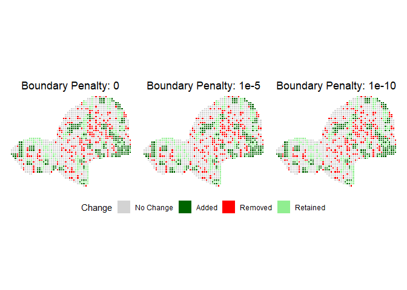

```r
patchwork::wrap_plots(plot_minpatch(result3, title = "Boundary Penalty: 0"),
                      plot_minpatch(result4, title = "Boundary Penalty: 1e-5"),
                      plot_minpatch(result5, title = "Boundary Penalty: 1e-10"),
                      guides = "collect",
                      ncol = 3) &
  theme(legend.position = "bottom")
```

## 10.2 Selected planning units (baseline vs MinPatch runs)

We then check the resulting spatial solutions, but only focusing on the selected planning units.

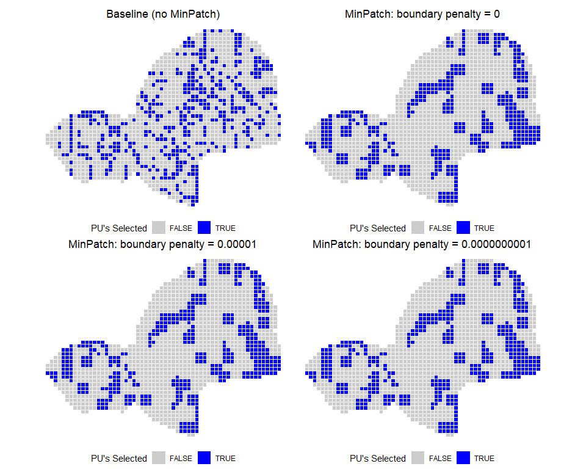

```r
# Helper to extract the solution and ensure a `solution_1` column
get_solution_with_solution1 <- function(x) {
  sol <- x$solution
  extra_cols <- setdiff(names(sol), names(x$planning_units))
  if (!"solution_1" %in% names(sol) && length(extra_cols) >= 1) {
    sol$solution_1 <- sol[[extra_cols[1]]]
  }
  sol
}

# Collect the boundary-penalty runs

# list of boundary penalties
boundary_penalties <- c(0, 1e-5, 1e-10)

# corresponding MinPatch results
boundary_results <- list(result3, result4, result5)

# extract solution objects with a solution_1 column
sol_list <- purrr::map(boundary_results, get_solution_with_solution1)

# Baseline solution plot (keep problem object p_base separate!)
p_base_plot <- plot_prioritizr(s_base) +
  ggtitle("Baseline (no MinPatch)")

# minPatch solutions for different boundary penalties
p_list <- purrr::map2(
  sol_list,
  boundary_penalties,
  ~ plot_prioritizr(.x) +
    ggtitle(paste0("MinPatch: boundary penalty = ", .y))
)

# assuming three boundary-penalty runs
p_1 <- p_list[[1]]
p_2 <- p_list[[2]]
p_3 <- p_list[[3]]

# 2×2 layout: baseline + 3 MinPatch variants
(p_base_plot | p_1) /
(p_2        | p_3)
```

## 10.3 Group summary table (all runs)

We summarise and compare all the runs using a table.

```r
# helper to grab one metric from the compare_solutions()$overall table
get_metric <- function(overall, column, metric) {
  out <- overall[[column]][overall$Metric == metric]
  if (length(out) == 0) NA_real_ else out  # safer: return NA if not found
}

# MinPatch results for different boundary penalties
boundary_penalties <- c(0, 1e-5, 1e-10)

minpatch_results_bp <- list(
  result3,
  result4,
  result5
)

# runtimes taken from your system.time() calls
minpatch_runtimes <- list(
  t3[["elapsed"]],
  t4[["elapsed"]],
  t5[["elapsed"]]
)

# baseline metrics from the first comparison (same "Original" across runs)
overall0 <- compare_solutions(minpatch_results_bp[[1]])$overall

baseline_row <- tibble::tibble(
  scenario            = "baseline",
  boundary_penalty    = NA_real_,
  selected_pu         = get_metric(overall0, "Original", "Selected Planning Units"),
  total_area          = get_metric(overall0, "Original", "Total Area"),
  n_patches           = get_metric(overall0, "Original", "Number of Patches"),
  valid_patches       = get_metric(overall0, "Original", "Valid Patches (>= min size)"),
  median_patch_size   = get_metric(overall0, "Original", "Median Patch Size"),
  planning_unit_cost  = get_metric(overall0, "Original", "Planning Unit Cost"),
  boundary_cost       = get_metric(overall0, "Original", "Boundary Cost"),
  total_cost          = get_metric(overall0, "Original", "Total Cost"),
  runtime_sec         = t_base[["elapsed"]]   # baseline runtime from your code
)

# metrics for each MinPatch run (different boundary penalties)
minpatch_rows <- purrr::pmap_dfr(
  list(
    minpatch_results_bp,
    as.list(boundary_penalties),
    minpatch_runtimes
  ),
  function(res, bp, rt) {
    overall <- compare_solutions(res)$overall

    tibble::tibble(
      scenario            = paste0("minpatch_bp", bp),
      boundary_penalty    = bp,
      selected_pu         = get_metric(overall, "MinPatch", "Selected Planning Units"),
      total_area          = get_metric(overall, "MinPatch", "Total Area"),
      n_patches           = get_metric(overall, "MinPatch", "Number of Patches"),
      valid_patches       = get_metric(overall, "MinPatch", "Valid Patches (>= min size)"),
      median_patch_size   = get_metric(overall, "MinPatch", "Median Patch Size"),
      planning_unit_cost  = get_metric(overall, "MinPatch", "Planning Unit Cost"),
      boundary_cost       = get_metric(overall, "MinPatch", "Boundary Cost"),
      total_cost          = get_metric(overall, "MinPatch", "Total Cost"),
      runtime_sec         = rt   # runtime from t3/t4/t5
    )
  }
)

# combine baseline + all MinPatch runs in one table
solution_summary <- dplyr::bind_rows(baseline_row, minpatch_rows)
solution_summary
```

```
#> # A tibble: 4 × 11
#>   scenario      boundary_penalty selected_pu total_area n_patches
#>   <chr>                    <dbl>       <dbl>      <dbl>     <dbl>
#> 1 baseline         NA                    452    4.07e11       176
#> 2 minpatch_bp0      0                    460    4.14e11        72
#> 3 minpatch_bp0…     0.00001              460    4.14e11        72
#> 4 minpatch_bp0…     0.0000000001         460    4.14e11        72
#> # ℹ 6 more variables: valid_patches <dbl>,
#> #   median_patch_size <dbl>, planning_unit_cost <dbl>,
#> #   boundary_cost <dbl>, total_cost <dbl>, runtime_sec <dbl>
```

The table shows that increasing the boundary penalty does not alter any of the reported metrics for this example.

## 10.4 Individual summaries (per run)

We show the individual summaries for every run in detail.

```r
library(knitr)

# MinPatch results for different boundary penalties
boundary_penalties <- c(0, 1e-5, 1e-10)

minpatch_results_bp <- list(
  result3,
  result4,
  result5
)

# Runtimes taken from system.time() calls
minpatch_runtimes <- c(
  t3[["elapsed"]],
  t4[["elapsed"]],
  t5[["elapsed"]]
)

# Loop over all MinPatch results (different boundary penalties)
for (i in seq_along(minpatch_results_bp)) {

  result      <- minpatch_results_bp[[i]]
  bp          <- boundary_penalties[i]
  runtime_sec <- minpatch_runtimes[i]

  # ---- Scenario header ----
  cat(
    "\n\n## Scenario: MinPatch with boundary penalty = ",
    format(bp, scientific = TRUE),
    "\n\n",
    sep = ""
  )

  # ---- Runtime ----
  if (!is.na(runtime_sec)) {
    cat(
      "**Runtime:** ",
      sprintf("%.2f", runtime_sec),
      " seconds\n\n",
      sep = ""
    )
  }

  # ---- MinPatch processing summary ----
  cat("### MinPatch processing summary\n\n")
  print_minpatch_summary(result)

  # ---- Compare solutions ----
  comparison <- compare_solutions(result)

  # ---- Overall comparison ----
  cat("\n### Overall solution comparison\n\n")
  knitr::kable(
    comparison$overall,
    caption = paste0(
      "Comparison between the original and MinPatch-adjusted solutions (boundary penalty = ",
      format(bp, scientific = TRUE),
      ")"
    )
  )

  # ---- Feature-level comparison ----
  cat("\n### Feature-level area comparison\n\n")
  knitr::kable(
    comparison$features,
    caption = paste0(
      "Feature-level area and proportional changes after MinPatch (boundary penalty = ",
      format(bp, scientific = TRUE),
      ")"
    )
  )

  # ---- Feature change summary ----
  cat("\n### Feature change summary\n\n")
  knitr::kable(
    comparison$summary,
    caption = paste0(
      "Summary of improved, reduced, and unchanged features (boundary penalty = ",
      format(bp, scientific = TRUE),
      ")"
    )
  )
}
```

```
#>
#>
#> ## Scenario: MinPatch with boundary penalty = 0e+00
#>
#> **Runtime:** 397.16 seconds
#>
#> ### MinPatch processing summary
#>
#> === MinPatch Processing Summary ===
#>
#> Patch Statistics:
#>   Initial patches: 176 (valid: 18)
#>   Final patches: 72 (valid: 35)
#>   Area change: 7201700669.16 (1.8%)
#>
#> Cost Breakdown:
#>   Planning unit cost: 414097.79
#>   Boundary cost: 0.00
#>   Total cost: 414097.79
#>   Selected units: 460
#>
#> Feature Representation:
#>   Total features: 15
#>   Targets met: 15
#>   Targets unmet: 0
#>   Mean proportion: 0.357
#>   Total shortfall: 0.00
#>
#>
#> === End Summary ===
#>
#> ### Overall solution comparison
#>
#>
#> ### Feature-level area comparison
#>
#>
#> ### Feature change summary
#>
#>
```

[output cut: 61 more lines]

```
#>   Targets met: 15
#>   Targets unmet: 0
#>   Mean proportion: 0.357
#>   Total shortfall: 0.00
#>
#>
#> === End Summary ===
#>
#> ### Overall solution comparison
#>
#>
#> ### Feature-level area comparison
#>
#>
#> ### Feature change summary
```

Similarly, the values across the individual summaries are the same.